# EDA for The Chocolate sales dataset_Hw3

Natalia Bonilla V.

2025-03-14

## Exploratory Data Analisis

Para este trabajo se escogio un database de Ventas de Chocolate, con venta en dolares. Descargado en Kaggle. https://www.kaggle.com/datasets/atharvasoundankar/chocolate-sales

## 1. Explorando los datos

### 2.1 Lectura de Chocolate Sales Dataset.

```r
df <- read.csv("Chocolate_Sales.csv")
```

### 1.2 Usando Head

```r
head(df, 3)
```

```
##     Sales.Person Country             Product      Date  Amount Boxes.Shipped
## 1 Jehu Rudeforth      UK     Mint Chip Choco 04-Jan-22 $5,320            180
## 2    Van Tuxwell   India       85% Dark Bars 01-Aug-22 $7,896             94
## 3   Gigi Bohling   India Peanut Butter Cubes 07-Jul-22 $4,501             91
```

### 1.3 Usando Tail

```r
tail(df, 3)
```

```
##          Sales.Person Country             Product      Date  Amount
## 1092     Ches Bonnell  Canada Organic Choco Syrup 26-Jul-22   $574
## 1093   Dotty Strutley   India             Eclairs 28-Jul-22 $2,086
## 1094 Karlen McCaffrey   India      70% Dark Bites 23-May-22 $5,075
##      Boxes.Shipped
## 1092           217
## 1093           384
## 1094           344
```

## 2. Estructura del DataSet

### 2.1 Usando summary

Genera un resumen estadístico de cada variable. Para variables numéricas, muestra la media, mediana, mínimo, máximo y cuartiles.

Para variables categóricas, muestra la frecuencia de cada categoría.

```r
summary(df)
```

```
##  Sales.Person         Country            Product              Date
##  Length:1094        Length:1094        Length:1094        Length:1094
##  Class :character   Class :character   Class :character   Class :character
##  Mode  :character   Mode  :character   Mode  :character   Mode  :character
##
##
##
##     Amount          Boxes.Shipped
##  Length:1094        Min.   :  1.0
##  Class :character   1st Qu.: 70.0
##  Mode  :character   Median :135.0
##                     Mean   :161.8
##                     3rd Qu.:228.8
##                     Max.   :709.0
```

### 2.2 Usando str

Para ver la estructura de mis datos, puedo hacerlo con str.

Aca debemos de tener en cuenta los tipos de datos que tiene cada columna ya que algunos se tendran que transformar para su uso estadistico.

```r
str(df)
```

```
## 'data.frame':    1094 obs. of  6 variables:
##  $ Sales.Person : chr  "Jehu Rudeforth" "Van Tuxwell" "Gigi Bohling" "Jan Morforth" ...
##  $ Country      : chr  "UK" "India" "India" "Australia" ...
##  $ Product      : chr  "Mint Chip Choco" "85% Dark Bars" "Peanut Butter Cubes" "Peanut Butter Cubes" ...
##  $ Date         : chr  "04-Jan-22" "01-Aug-22" "07-Jul-22" "27-Apr-22" ...
##  $ Amount       : chr  "$5,320 " "$7,896 " "$4,501 " "$12,726 " ...
##  $ Boxes.Shipped: int  180 94 91 342 184 38 176 73 59 102 ...
```

En la estructura anterior, se puede apreciar que en _**Amount* se muestra como *char*, entonces a continuacion procederemos a eliminar el signo de dolar($), la coma(,) y convertirlo en numero, para poder trabajar con los datos.

Para lograrlo se investigó la funcion **gsub**, que significa “Global Substitution”, y se usa para reemplazar patrones dentro de un string.

Formula: gsub(pattern, replacement, x) donde x = a la columna del df. En este caso df$Amount.

El patron es una expresion regular, “*[\$, ]*”, y esto se reemplaza por -> “” que no tiene nada.

Finalmente, se convierte en numero con la funcion as.numeric()

```r
df$Amount <- as.numeric(gsub("[\\$, ]", "", df$Amount))
summary(df)
```

```
##  Sales.Person         Country            Product              Date
##  Length:1094        Length:1094        Length:1094        Length:1094
##  Class :character   Class :character   Class :character   Class :character
##  Mode  :character   Mode  :character   Mode  :character   Mode  :character
##
##
##
##      Amount      Boxes.Shipped
##  Min.   :    7   Min.   :  1.0
##  1st Qu.: 2390   1st Qu.: 70.0
##  Median : 4868   Median :135.0
##  Mean   : 5652   Mean   :161.8
##  3rd Qu.: 8027   3rd Qu.:228.8
##  Max.   :22050   Max.   :709.0
```

### 2.3 Conversion a Factor

```r
df$Sales.Person <- as.factor(df$Sales.Person)
sort(table(df$Sales.Person), decreasing = TRUE)
```

```
##
##       Kelci Walkden         Brien Boise         Van Tuxwell      Beverie Moffet
##                  54                  53                  51                  50
## Dennison Crosswaite          Oby Sorrel        Ches Bonnell        Gigi Bohling
##                  49                  49                  48                  47
##    Karlen McCaffrey      Curtice Advani         Kaine Padly     Madelene Upcott
##                  47                  46                  45                  45
##      Marney O'Breen        Barr Faughny     Gunar Cockshoot      Jehu Rudeforth
##                  45                  43                  43                  43
##     Roddy Speechley      Mallorie Waber      Andria Kimpton        Jan Morforth
##                  43                  41                  39                  39
##        Husein Augar      Dotty Strutley Rafaelita Blaksland      Wilone O'Kielt
##                  38                  36                  34                  34
##      Camilla Castle
##                  32
```

Aca convertimos `Country` a factor. Mas adelante veremos un grafico para observar visualmente el pais con mayor venta

```r
country_factor <- as.factor(df$Country)
sort(table(country_factor), decreasing = TRUE)
```

```
## country_factor
##   Australia       India         USA          UK      Canada New Zealand
##         205         184         179         178         175         173
```

## 3. Metricas Estadisticas

Vamos a explorar el promedio, la media.

Acá estamos usando **num_cols** para almacenar todos los rows de las columnas que solo son numericas con sapply.

```r
num_cols <- df[, sapply(df, is.numeric)]
head(num_cols, 5)
```

```
##   Amount Boxes.Shipped
## 1   5320           180
## 2   7896            94
## 3   4501            91
## 4  12726           342
## 5  13685           184
```

### 3.2 Minimos

Aca vamos aplicar el *min* para **num_cols**

```r
min_values <- apply(num_cols, 2, min, na.rm = TRUE)
min_values
```

```
##        Amount Boxes.Shipped
##             7             1
```

### 3.3 Maximos

Lo mismo para el *max* en **num_cols**

```r
max_values <- apply(num_cols, 2, max, na.rm = TRUE)
max_values
```

```
##        Amount Boxes.Shipped
##         22050           709
```

### 3.4 Promedios

Aplicaremos la misma formula para revisar los promedios

```r
mean_values <- apply(num_cols, 2, mean, na.rm = TRUE)
mean_values
```

```
##        Amount Boxes.Shipped
##      5652.308       161.798
```

### 3.5 Mediana

Con la mediana verificaremos que tantos valores atipicos tiene el promedio de datos

```r
median_values <- apply(num_cols, 2, median, na.rm = TRUE)
median_values
```

```
##        Amount Boxes.Shipped
##        4868.5         135.0
```

### 3.6 Desviacion Estandart (DE)

Revisaremos si tenemos una DE alta o baja con respecto al promedio

```r
sd_values <- apply(num_cols, 2, sd, na.rm = TRUE)
sd_values
```

```
##        Amount Boxes.Shipped
##     4102.4420      121.5441
```

### 3.7 Correlacion entre Amount y Box shipped

```r
cor(df$Amount, df$Boxes.Shipped)
```

```
## [1] -0.01882685
```

## 4. Analisis de las Variables Amount y Box shipped

No existe una corelacion entre `Amount` y `Boxes.Shipped`. Las ventas no dependen de la cantidad de cajas enviadas.

### 4.1 Analisis Amount

- La diferencia entre el valor `min_values` y el `max_values`}}` para **Amount** es muy significativa, lo que indica que hay amplia variabilidad en los montos de las ventas.
- La `median_values` < `mean_values` lo que quiere decir que hay valores muy altos que llevan la media hacia arriba.
- La `sd_values` es bastante alta, lo qeu confirma la alta variabilidad en los montos de las ventas.

## 5. Visualizaciones

Los Graficos que vamos a utilizar en este caso seran:

- Scatterplot: Grafico de dispersion para visualizar la relacion entre *Amount* y *Boxes.Shipped* y ver graficamente lo que vimos en numeros anteriores.
- Boxplot: Para ver los valores atipicos de *Amount* y *Boxes.Shipped*.
- Bar: Graficos en los que veremos rankings de mejores y peores ventas, vendedores, paises.
- Line: Con este podremos visualizar cuando se vendio mas.

Librerias a utilizar

```r
library(ggplot2)
library(dplyr)
library(lubridate)
```

### 5.1 Scatterplot

Aca mostraremos la distribución de los puntos de datos.

- La línea roja muestra la tendencia lineal entre las variables. No hay regresion lineal.
- Los puntos que se alejan mucho de la línea de regresión podrían ser valores atípicos.

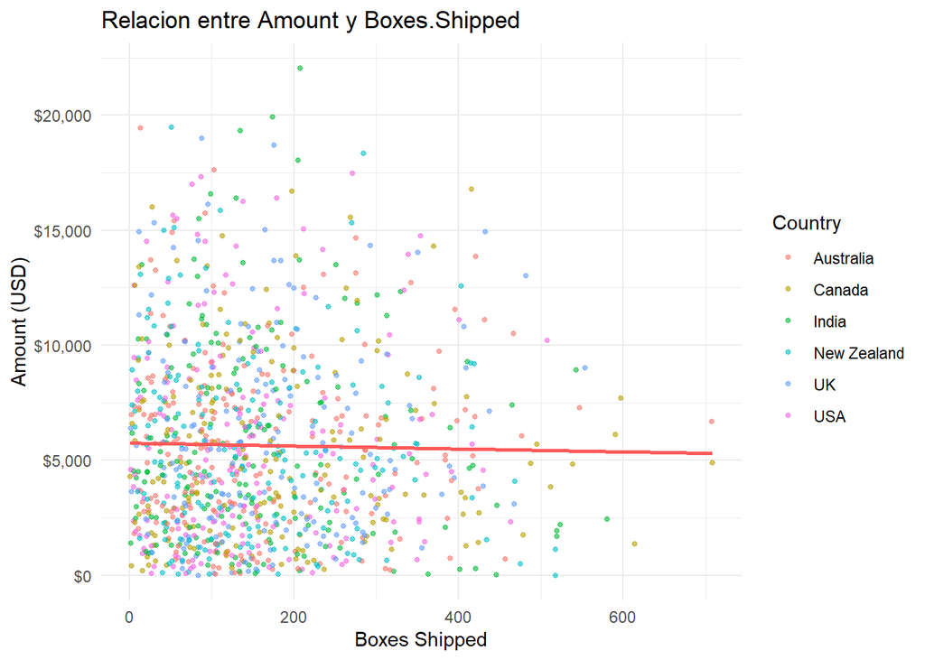

```r
ggplot(df, aes(x=Boxes.Shipped, y = Amount, color=Country))+
  geom_point(size=1, alpha = 0.6) +
  geom_smooth(method = "lm", se = FALSE, color = "#ff5959") +
  labs(title = "Relacion entre Amount y Boxes.Shipped",
       x = "Boxes Shipped",
       y = "Amount (USD)") +
  scale_y_continuous(labels = scales::label_dollar()) +
  theme_minimal() #+
```

### 5.2 Boxplot

Como la DE es larga, habian sospechas de outliers, aca podemos identificar esos valores atipicos visualmente.

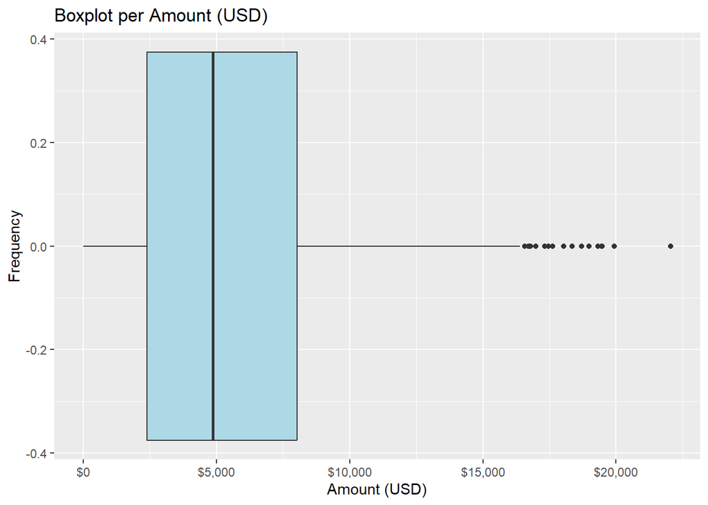

```r
ggplot(df, aes(x = Amount)) +
  geom_boxplot(fill="lightblue") +
  scale_x_continuous(labels = scales::label_dollar()) +
  labs(title = "Boxplot per Amount (USD)",
       x = "Amount (USD)",
       y = "Frequency")
```

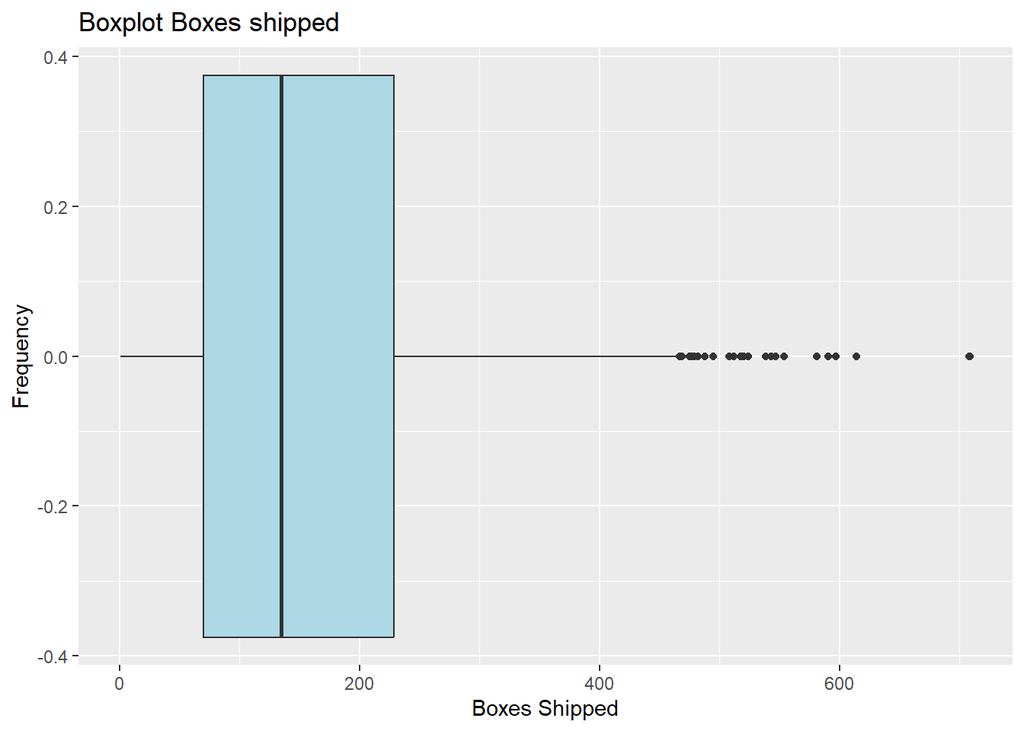

```r
ggplot(df, aes(x = Boxes.Shipped)) +
  geom_boxplot(fill="lightblue") +
  labs(title = "Boxplot Boxes shipped",
       x = "Boxes Shipped",
       y = "Frequency")
```

### 5.3 Bar

Aca veermos los distintos usos del Grafico de Barras, funciona muy bien para rankings

### 5.3.1 Rankings

Para el *new_topN **usamos “%>%” que es el** pipe operator** del paquete *dplyr* que nos ayuda a concatenar varias operaciones. Entonces pasamos df, a la siguiente funcion de la cadena.

**Arrange()** se utiliza para reordenar las filas de un data frame basándose en los valores de una o más columnas. Mientras que **desc()** nos ordena de mayor a menor.

Para un Top N usaremos esta funcion la cual podremos ultilizar atravez de nuestro EDA y podremos definir si es un rancking mas o menos venats con head o tail.

```r
new_topN <- function(topN, rank = "head") {
  df %>%
    group_by(Product) %>%               # Group by Product
    summarize(Amount = sum(Amount)) %>%  # Sum sales for each product
    arrange(desc(Amount)) %>%            # Sort in descending order
    { if (rank == "head") head(., topN) else tail(., topN) }  # Apply head or tail dynamically
}
```

Aqui usamos la funcion *scale_x_continuous** para darle formato a de dolares al eje X

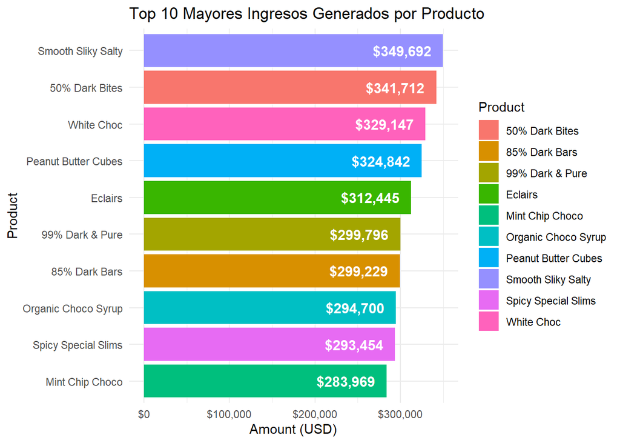

```r
ggplot(new_topN(10, "head"), aes(x = Amount, y = reorder(Product, Amount), fill = Product)) +
  geom_bar(stat = "identity") +
  geom_text(aes(label = scales::label_dollar()(Amount)),
            hjust = 1.2, color = "white", size = 4, fontface = "bold") +
  scale_x_continuous(labels = scales::label_dollar()) +
  labs(title = "Top 10 Mayores Ingresos Generados por Producto",
       x = "Amount (USD)", y = "Product") +
  theme_minimal()
```

### 5.3.1.2 Top 5 producto menos vendido

Aca se presenta un grafico de barras, mostrando el top 5 de los productos menos vendidos.

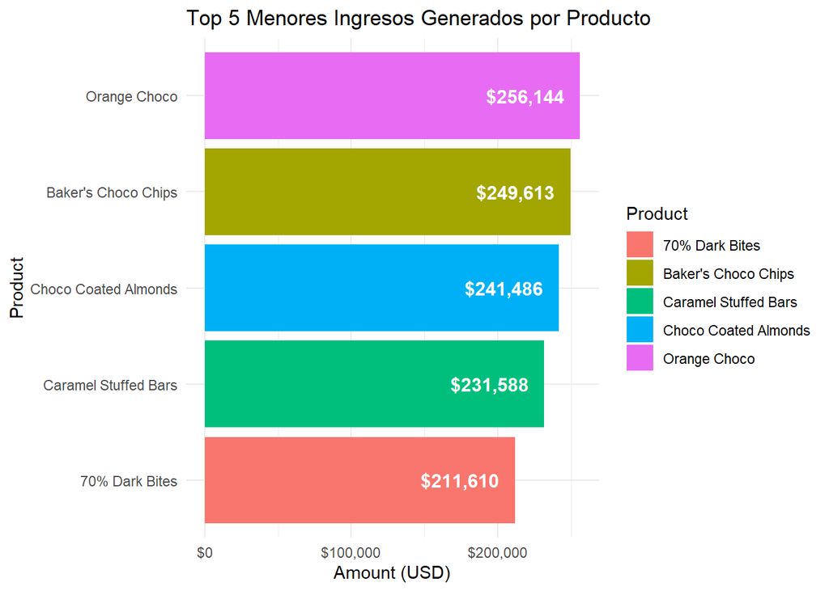

```r
ggplot(new_topN(5, "tail"), aes(x = Amount, y = reorder(Product, Amount), fill = Product)) +
  geom_bar(stat = "identity") +
  geom_text(aes(label = scales::label_dollar()(Amount)),  # Add formatted labels
            hjust = 1.2, color = "white", size = 4, fontface = "bold") +  # Adjust label position & color
  scale_x_continuous(labels = scales::label_dollar()) +
  labs(title = "Top 5 Menores Ingresos Generados por Producto", x = "Amount (USD)", y = "Product") +
  theme_minimal()
```

### 5.3.1.3 Top 10 Mejores Vendedores

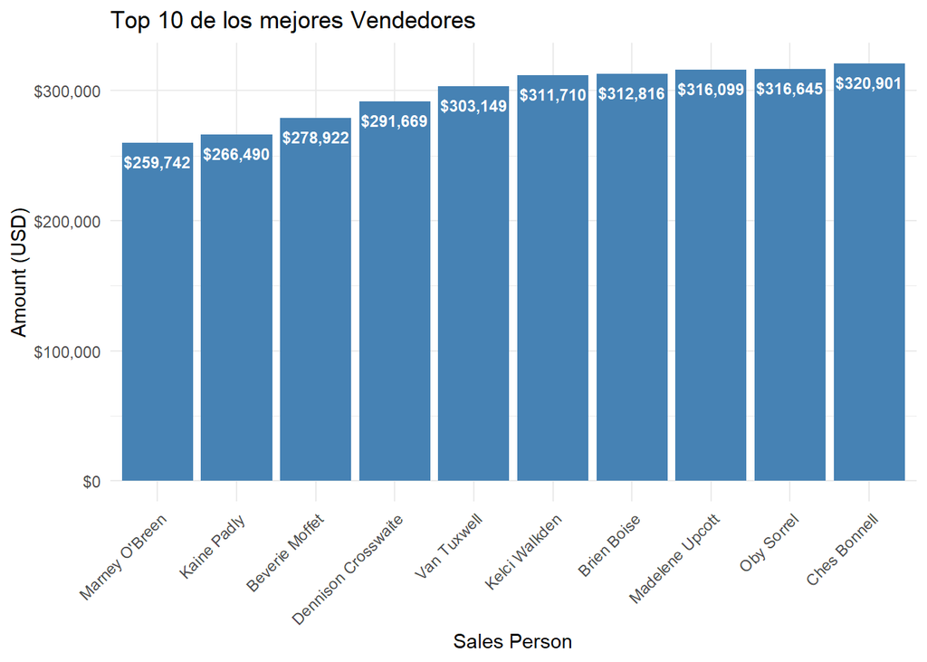

```r
sales_rate <- df %>%
  group_by(Sales.Person) %>%
  summarize(Total_Amount = sum(Amount)) %>%
  arrange(desc(Total_Amount)) %>%  # Sort from highest to lowest
  slice(1:10)

ggplot(sales_rate, aes(x = reorder(Sales.Person, Total_Amount), y = Total_Amount)) +
  geom_bar(stat = "identity", fill = "#4682B4") +
  geom_text(aes(label = scales::label_dollar()(Total_Amount)),  # Add formatted labels
          hjust = 0.5, vjust = 2, color = "white", size = 3, fontface = "bold") +
  scale_y_continuous(labels = scales::label_dollar()) +
  labs(title = "Top 10 de los mejores Vendedores", x = "Sales Person", y = "Amount (USD)") +
  scale_fill_viridis_d(option = "C") +  # "C" is a blueish Viridis scale
  theme_minimal() +
  theme(axis.text.x = element_text(angle=45, hjust = 1))
```

### 5.3.2 Productos vendidos por Pais

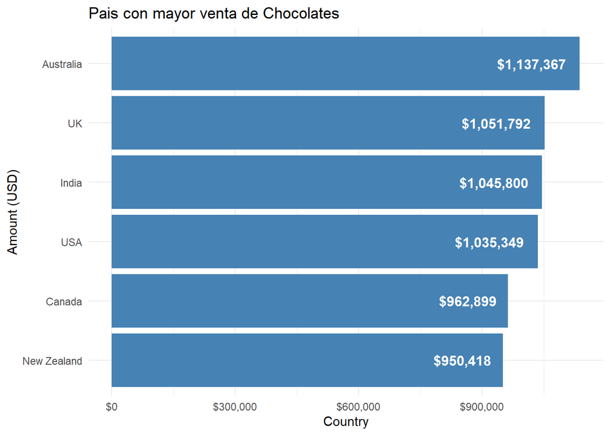

```r
country_sales <- df %>%
  group_by(Country) %>%
  summarize(Total_Amount = sum(Amount)) %>%
  arrange(desc(Total_Amount))  # Sort from highest to lowest

ggplot(country_sales, aes(x = Total_Amount, y = reorder(Country, Total_Amount))) +
  geom_bar(stat = "identity", fill = "#4682B4") +
  geom_text(aes(label = scales::label_dollar()(Total_Amount)),  # Add formatted labels
          hjust = 1.2, color = "white", size = 4, fontface = "bold") +
  scale_x_continuous(labels = scales::label_dollar()) +
  labs(title = "Pais con mayor venta de Chocolates", x = "Country", y = "Amount (USD)") +
  scale_fill_viridis_d(option = "C") +  # "C" is a blueish Viridis scale
  theme_minimal()
```

### 5.4 Grafico Lineas

Vamos a darle formato a `Date` para poder trabajar con el y poder visualizar el comportamiento de los Datos.

```r
library(lubridate)
df$Date <- as.Date(df$Date, format = "%d-%b-%y")
df$Month <- format(df$Date, "%Y-%m")
df$month <- floor_date(df$date, "month")

monthly_sales <- aggregate(Amount ~ Month, data = df, sum)
monthly_sales <- monthly_sales[order(monthly_sales$Amount, decreasing = TRUE), ]
```

### 5.4.1 Comportamiento de las Ventas por mes

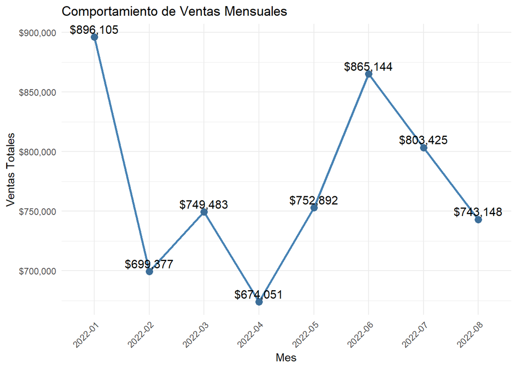

```r
ggplot(monthly_sales, aes(x = Month, y = Amount, group = 1)) +
  geom_line(color = "#4682B4", size = 1) +
  geom_point(color = "#3c6e99", size = 3) +
  geom_text(aes(label = scales::label_dollar()(Amount)),  # Add formatted labels
          hjust = 0.5, vjust = -0.4, color = "black", size = 4) +
  scale_y_continuous(labels = scales::label_dollar()) +
  labs(title = "Comportamiento de Ventas Mensuales",
       x = "Mes",
       y = "Ventas Totales") +
  theme_minimal() +
  theme(axis.text.x = element_text(angle = 45, hjust = 1))
```